# COVID-19

Mike

3/12/2020

## Analysis of COVID-19 (SARS-CoV-2)

Check back for weekly updates as this is very much a work in progress.

### Date Parsing and Formatting

Including the code below as it’s nearly boilerplate for date formatting. In some cases the strsplit will need to be adjusted, but I find it much more efficient to parse and reformat a date each time than try to accomodate different date formats across datasets.

```r
# Date to char for parsing and conversion
data$date <- as.character(data$date)

# Parse the date
data$year<-sapply(data$date, function(x) as.numeric(strsplit(x,"/")[[1]][3]))
data$month<-sapply(data$date, function(x) as.numeric(strsplit(x,"/")[[1]][1]))
data$day<-sapply(data$date, function(x) as.numeric(strsplit(x,"/")[[1]][2]))

# Put us back in the year 2000
data$year <- (data$year + 2000)

# Reformat date into y-m-d
data$date<-as.Date(paste0(data$year,'-',data$month,'-',data$day), format="%Y-%m-%d")

# Add some weekdays for good measure
data$weekday <- weekdays(as.Date(data$date))

# Put weekdays in order
data$weekday <- ordered(data$weekday, levels=c("Monday", "Tuesday", "Wednesday", "Thursday", "Friday", "Saturday", "Sunday"))


# Set X axis limits ------------------------------------------------------------------------------- Must update with data refresh
time <- as.POSIXct(strptime(c("2020-01-22","2020-03-15"), format = "%y-%m-%d"))
```

## Time Series Heat Plot

At present, with China as a large confirmed case outlier (over 80,000), I rescaled the confirmed cases using a limit of 10,000 to give greater visibility to lower and emerging counts.

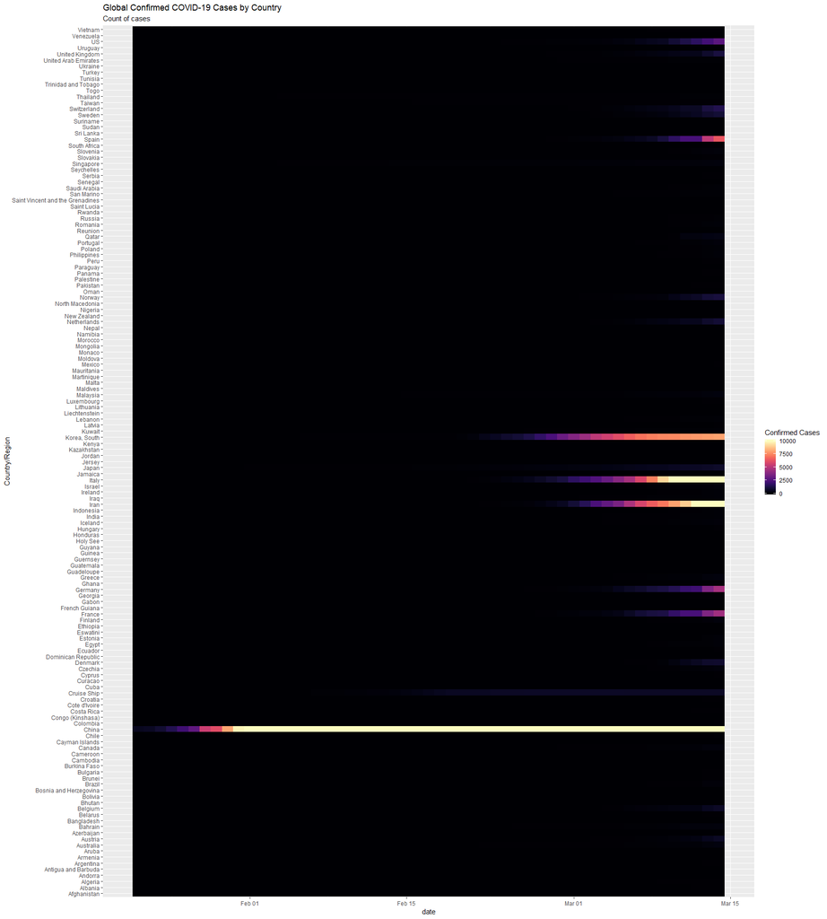

## Confirmed Cases Trend

Using ggplotly for an interactive plot, here are the Country/Region’s in the top 20 for confirmed cases plotted since the pandemic started.

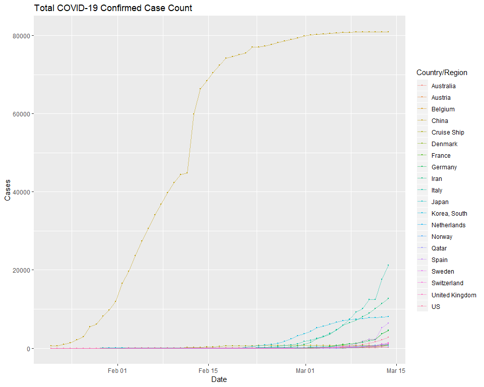

## COVID-19 Death Trend

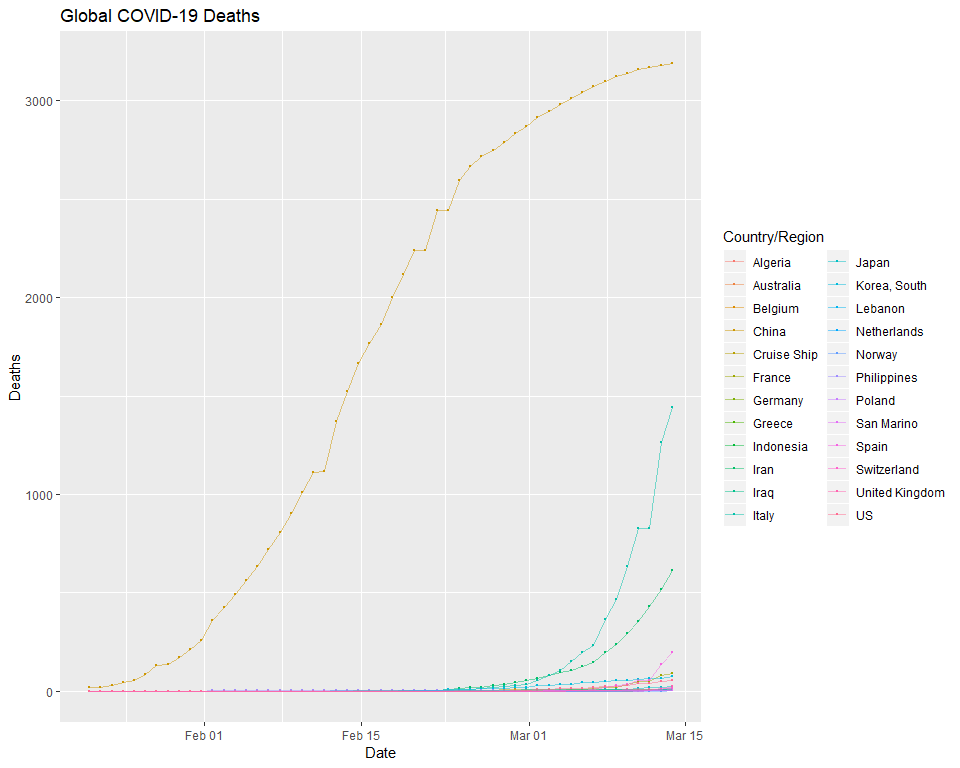

## COVID-19 Confirmed Cases and Deaths

Graphs of relationship between confirmed cases and death for highly impacted countries.

### China

Example code included, overlaying two area plots from seperate data frames. I wasn’t able to identify a straightforward method to include a plot legend– comment below if you have one!

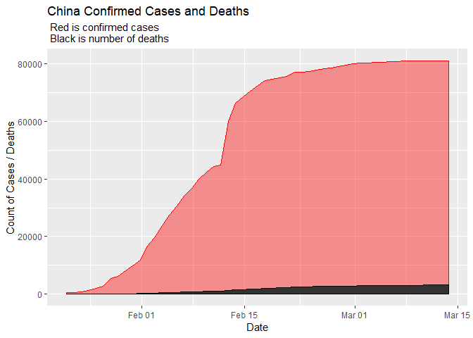

```r
ggplot() +
      geom_area(data=(data %>%
                  filter(`Country/Region` %in% "China") %>%
                  group_by(date, count)),
                  aes(x=as.POSIXct(date),y=count), color='red', alpha=0.4, fill = 'red') +
      geom_area(data=(death %>%
                  filter(`Country/Region` %in% "China") %>%
                  group_by(date, count)),
                  aes(x=as.POSIXct(date),y=count), color='black') +
                  labs(title="China Confirmed Cases and Deaths",
                       subtitle = " Red is confirmed cases \n Black is number of deaths") +
                  xlab("Date") +
                  ylab("Count of Cases / Deaths")
```

### US

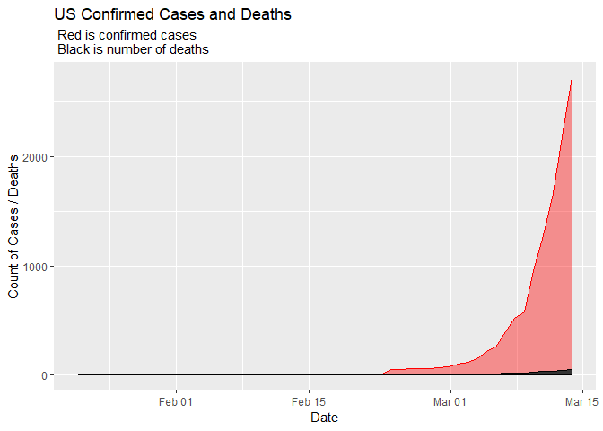

### Italy

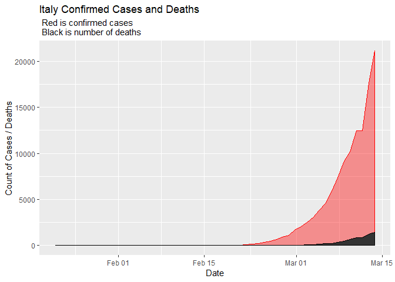

## World Map of COVID-19

Point size reflects number of cases / deaths

### Worldwide Confirmed Cases

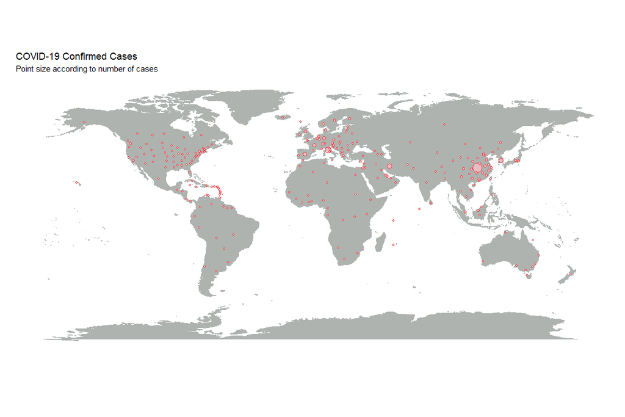

### Worldwide COVID-19 Deaths

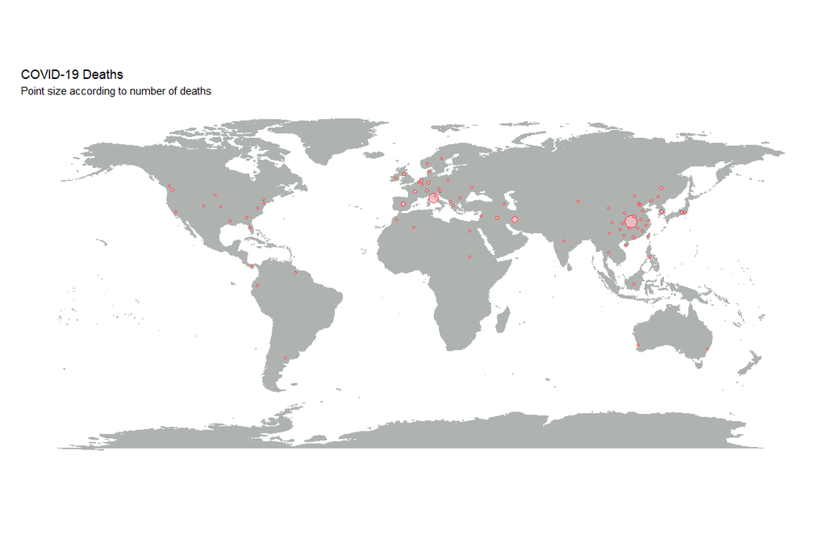

## US Map of COVID-19

### US Confirmed Cases

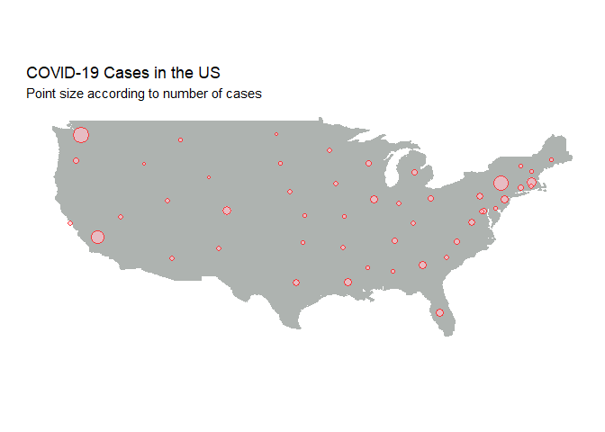

### US COVID-19 Deaths

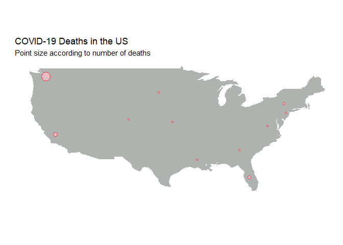